# Project: Investigate TMDB (The Movies Database) Dataset

- Introduction
- Data Wrangling
- Exploratory Data Analysis
  - Comparisons
  - Popularity
  - Profitability
  - Frequency
- Conclusions

## Introduction

### Hello! This is my first project exploring a dataset, thanks to FWD program and Udacity Nanodegree.

### After going through the provided datasets, I found myself attracted to the TMDB dataset due to my passion for watching movies as well as watching a huge number of movies that inspired me throug this project.

## Let's have a small idea about this dataset:

### This dataset was collected by Kaggle through TMDB Website with more than 10,000 movies as rows(entries) and more than 20 columns of different types of information about these movies

## I have already gone through the dataset and checked other projects for inspiration and made up my mind about how we are going to explore it;

### The dataset provides for each movie: popularity, revenue, budget, list of cast, director, votes, genre, ....etc

### So, I have devided my questions to 4 categories:

### 1: **Comparisons**: Here we are going to compare the most and least value for some properties and see which movies

### 2: **Popularity**: Here we are going to see what properties affect popularity of a movie

### 3: **Profitability**: Here we are going to see what properties affect profitability of a movie

### 4: **Frequency**: finally we are going to check the frequency of an actor, director, genre,...etc

## So! are you ready to explore this dataset with me and see what interesting findings we could extract? Let's go!

### First, Let's import the main libraries (pandas, numpy, and matplotlib for plotting)

```python
import pandas as pd
import numpy as np
from datetime import datetime
import matplotlib.pyplot as plt
%matplotlib inline
import seaborn as sns
sns.set()
```

# Data Wrangling

## General Properties

Second, let's load our dataset here and explore its properties

```python
df = pd.read_csv('tmdb-movies.csv')
df.head()
```

|  | id | imdb_id | popularity | budget | revenue | original_title | cast | homepage | director | tagline | ... | overview | runtime | genres | production_companies | release_date | vote_count | vote_average | release_year | budget_adj | revenue_adj |
| --- | --- | --- | --- | --- | --- | --- | --- | --- | --- | --- | --- | --- | --- | --- | --- | --- | --- | --- | --- | --- | --- |
| 0 | 135397 | tt0369610 | 32.985763 | 150000000 | 1513528810 | Jurassic World | Chris Pratt\|Bryce Dallas Howard\|Irrfan Khan\|Vi... | http://www.jurassicworld.com/ | Colin Trevorrow | The park is open. | ... | Twenty-two years after the events of Jurassic ... | 124 | Action\|Adventure\|Science Fiction\|Thriller | Universal Studios\|Amblin Entertainment\|Legenda... | 6/9/15 | 5562 | 6.5 | 2015 | 1.379999e+08 | 1.392446e+09 |
| 1 | 76341 | tt1392190 | 28.419936 | 150000000 | 378436354 | Mad Max: Fury Road | Tom Hardy\|Charlize Theron\|Hugh Keays-Byrne\|Nic... | http://www.madmaxmovie.com/ | George Miller | What a Lovely Day. | ... | An apocalyptic story set in the furthest reach... | 120 | Action\|Adventure\|Science Fiction\|Thriller | Village Roadshow Pictures\|Kennedy Miller Produ... | 5/13/15 | 6185 | 7.1 | 2015 | 1.379999e+08 | 3.481613e+08 |
| 2 | 262500 | tt2908446 | 13.112507 | 110000000 | 295238201 | Insurgent | Shailene Woodley\|Theo James\|Kate Winslet\|Ansel... | http://www.thedivergentseries.movie/#insurgent | Robert Schwentke | One Choice Can Destroy You | ... | Beatrice Prior must confront her inner demons ... | 119 | Adventure\|Science Fiction\|Thriller | Summit Entertainment\|Mandeville Films\|Red Wago... | 3/18/15 | 2480 | 6.3 | 2015 | 1.012000e+08 | 2.716190e+08 |
| 3 | 140607 | tt2488496 | 11.173104 | 200000000 | 2068178225 | Star Wars: The Force Awakens | Harrison Ford\|Mark Hamill\|Carrie Fisher\|Adam D... | http://www.starwars.com/films/star-wars-episod... | J.J. Abrams | Every generation has a story. | ... | Thirty years after defeating the Galactic Empi... | 136 | Action\|Adventure\|Science Fiction\|Fantasy | Lucasfilm\|Truenorth Productions\|Bad Robot | 12/15/15 | 5292 | 7.5 | 2015 | 1.839999e+08 | 1.902723e+09 |
| 4 | 168259 | tt2820852 | 9.335014 | 190000000 | 1506249360 | Furious 7 | Vin Diesel\|Paul Walker\|Jason Statham\|Michelle ... | http://www.furious7.com/ | James Wan | Vengeance Hits Home | ... | Deckard Shaw seeks revenge against Dominic Tor... | 137 | Action\|Crime\|Thriller | Universal Pictures\|Original Film\|Media Rights ... | 4/1/15 | 2947 | 7.3 | 2015 | 1.747999e+08 | 1.385749e+09 |

5 rows × 21 columns

### So, the dataset has 21 columns, and we can see that some columns such as "cast" having a "|" between each name, which is not best for data manipulation

```python
df.info()
```

```
<class 'pandas.core.frame.DataFrame'>
RangeIndex: 10866 entries, 0 to 10865
Data columns (total 21 columns):
 #   Column                Non-Null Count  Dtype
---  ------                --------------  -----
 0   id                    10866 non-null  int64
 1   imdb_id               10856 non-null  object
 2   popularity            10866 non-null  float64
 3   budget                10866 non-null  int64
 4   revenue               10866 non-null  int64
 5   original_title        10866 non-null  object
 6   cast                  10790 non-null  object
 7   homepage              2936 non-null   object
 8   director              10822 non-null  object
 9   tagline               8042 non-null   object
 10  keywords              9373 non-null   object
 11  overview              10862 non-null  object
 12  runtime               10866 non-null  int64
 13  genres                10843 non-null  object
 14  production_companies  9836 non-null   object
 15  release_date          10866 non-null  object
 16  vote_count            10866 non-null  int64
 17  vote_average          10866 non-null  float64
 18  release_year          10866 non-null  int64
 19  budget_adj            10866 non-null  float64
 20  revenue_adj           10866 non-null  float64
dtypes: float64(4), int64(6), object(11)
memory usage: 1.7+ MB
```

### It shows up here that there are 10866 movies, however not all the columns are filled up, there is much missing data

```python
df.dtypes
```

```
id                        int64
imdb_id                  object
popularity              float64
budget                    int64
revenue                   int64
original_title           object
cast                     object
homepage                 object
director                 object
tagline                  object
keywords                 object
overview                 object
runtime                   int64
genres                   object
production_companies     object
release_date             object
vote_count                int64
vote_average            float64
release_year              int64
budget_adj              float64
revenue_adj             float64
dtype: object
```

### Up here we checked the data type of each column, I can see that these types are so far so good, unless we find out any issue later on, we can then manipulate the data types to our favor. Only, the release date column need to be "datetime" type

```python
df.columns
```

```
Index(['id', 'imdb_id', 'popularity', 'budget', 'revenue', 'original_title',
       'cast', 'homepage', 'director', 'tagline', 'keywords', 'overview',
       'runtime', 'genres', 'production_companies', 'release_date',
       'vote_count', 'vote_average', 'release_year', 'budget_adj',
       'revenue_adj'],
      dtype='object')
```

### After checking the columns, I decided to drop the columns that I don't need in my analysis

## Data Cleaning

### - Of course I am not going to use 'ID' or "IMDB ID' in my analysis, so I am going to drop them

### - Also, I dont need 'Home Page', 'Tagline', 'Keywords' and 'Overview'

### - There are two types of budget and revenue; the real numbers ('budget', 'revenue') columns, and ('budget_adj', 'revenue_adj') columns which according to the documentation they are the budget and revenue but accounting for inflation over the years. So, I thought that *_adj columns will give more accurate analysis, so I am going to drop 'budget' and 'revenue' columns

### - I am going to count on the release year in my analysis so I am not going to use the release date, will drop that as well

### - Votes, and production company columns are irrelevant to my analysis, so we will drop them

```python
drop_columns = ['imdb_id','homepage','tagline','keywords','overview','budget','revenue','vote_count','vote_average','id','production_companies','release_date']
df.drop(drop_columns,axis=1,inplace=True)
```

```python
df.info()
```

```
<class 'pandas.core.frame.DataFrame'>
RangeIndex: 10866 entries, 0 to 10865
Data columns (total 9 columns):
 #   Column          Non-Null Count  Dtype
---  ------          --------------  -----
 0   popularity      10866 non-null  float64
 1   original_title  10866 non-null  object
 2   cast            10790 non-null  object
 3   director        10822 non-null  object
 4   runtime         10866 non-null  int64
 5   genres          10843 non-null  object
 6   release_year    10866 non-null  int64
 7   budget_adj      10866 non-null  float64
 8   revenue_adj     10866 non-null  float64
dtypes: float64(3), int64(2), object(4)
memory usage: 764.1+ KB
```

### Let's check if the numeric columns contain NaN values masked as zeros

```python
df.query('budget_adj == 0')
```

|  | popularity | original_title | cast | director | runtime | genres | release_year | budget_adj | revenue_adj |
| --- | --- | --- | --- | --- | --- | --- | --- | --- | --- |
| 30 | 3.927333 | Mr. Holmes | Ian McKellen\|Milo Parker\|Laura Linney\|Hattie M... | Bill Condon | 103 | Mystery\|Drama | 2015 | 0.0 | 2.700677e+07 |
| 36 | 3.358321 | Solace | Abbie Cornish\|Jeffrey Dean Morgan\|Colin Farrel... | Afonso Poyart | 101 | Crime\|Drama\|Mystery | 2015 | 0.0 | 2.056620e+07 |
| 72 | 2.272044 | Beyond the Reach | Michael Douglas\|Jeremy Irvine\|Hanna Mangan Law... | Jean-Baptiste LÃ©onetti | 95 | Thriller | 2015 | 0.0 | 4.222338e+04 |
| 74 | 2.165433 | Mythica: The Darkspore | Melanie Stone\|Kevin Sorbo\|Adam Johnson\|Jake St... | Anne K. Black | 108 | Action\|Adventure\|Fantasy | 2015 | 0.0 | 0.000000e+00 |
| 75 | 2.141506 | Me and Earl and the Dying Girl | Thomas Mann\|RJ Cyler\|Olivia Cooke\|Connie Britt... | Alfonso Gomez-Rejon | 105 | Comedy\|Drama | 2015 | 0.0 | 0.000000e+00 |
| ... | ... | ... | ... | ... | ... | ... | ... | ... | ... |
| 10860 | 0.087034 | Carry On Screaming! | Kenneth Williams\|Jim Dale\|Harry H. Corbett\|Joa... | Gerald Thomas | 87 | Comedy | 1966 | 0.0 | 0.000000e+00 |
| 10861 | 0.080598 | The Endless Summer | Michael Hynson\|Robert August\|Lord 'Tally Ho' B... | Bruce Brown | 95 | Documentary | 1966 | 0.0 | 0.000000e+00 |
| 10862 | 0.065543 | Grand Prix | James Garner\|Eva Marie Saint\|Yves Montand\|Tosh... | John Frankenheimer | 176 | Action\|Adventure\|Drama | 1966 | 0.0 | 0.000000e+00 |
| 10863 | 0.065141 | Beregis Avtomobilya | Innokentiy Smoktunovskiy\|Oleg Efremov\|Georgi Z... | Eldar Ryazanov | 94 | Mystery\|Comedy | 1966 | 0.0 | 0.000000e+00 |
| 10864 | 0.064317 | What's Up, Tiger Lily? | Tatsuya Mihashi\|Akiko Wakabayashi\|Mie Hama\|Joh... | Woody Allen | 80 | Action\|Comedy | 1966 | 0.0 | 0.000000e+00 |

5696 rows × 9 columns

### OOPS, as expected, it seems to be there are alot of zeros embedded in these columns, so lets replace those zeros with NaN values

```python
zeros_list = ['revenue_adj','budget_adj','runtime']
df[zeros_list] = df[zeros_list].replace(0,np.nan)
```

### Let's replace the NaN values with the mean of each column

```python
df.budget_adj.fillna(df.budget_adj.mean(), inplace=True)
df.revenue_adj.fillna(df.revenue_adj.mean(), inplace=True)
df.runtime.fillna(df.runtime.mean(), inplace=True)
```

### Let's drop duplicates

```python
df.drop_duplicates(inplace=True)
```

### And the rows with NaN values

```python
df.dropna(inplace=True)
```

### We found earlier that the string type columns are separated with "|" so let's separate them into sublists

### Remove " | " from genres and cast columns

```python
df.genres = df.genres.str.split(pat='|')
df.cast = df.cast.str.split(pat='|')
```

### Let's check the final shape of the dataframe after cleaning

```python
df.head(1)
```

|  | popularity | original_title | cast | director | runtime | genres | release_year | budget_adj | revenue_adj |
| --- | --- | --- | --- | --- | --- | --- | --- | --- | --- |
| 0 | 32.985763 | Jurassic World | [Chris Pratt, Bryce Dallas Howard, Irrfan Khan... | Colin Trevorrow | 124.0 | [Action, Adventure, Science Fiction, Thriller] | 2015 | 1.379999e+08 | 1.392446e+09 |

```python
df.info()
```

```
<class 'pandas.core.frame.DataFrame'>
Int64Index: 10731 entries, 0 to 10865
Data columns (total 9 columns):
 #   Column          Non-Null Count  Dtype
---  ------          --------------  -----
 0   popularity      10731 non-null  float64
 1   original_title  10731 non-null  object
 2   cast            10731 non-null  object
 3   director        10731 non-null  object
 4   runtime         10731 non-null  float64
 5   genres          10731 non-null  object
 6   release_year    10731 non-null  int64
 7   budget_adj      10731 non-null  float64
 8   revenue_adj     10731 non-null  float64
dtypes: float64(4), int64(1), object(4)
memory usage: 838.4+ KB
```

### Let's do a quick check with a histogram plot to all numeric columns

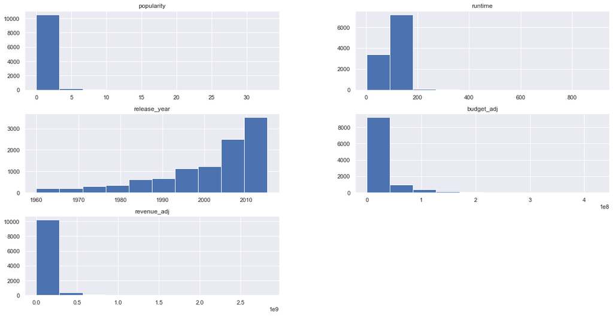

```python
df.hist(figsize=(20,10));
```

## Our Columns are in good shape, So let's go to the next step after cleaning our data frame, which is the most interesting step, The **EDA** step

# Exploratory Data Analysis

# Comaprisons

### As mentioned in the introduction section, this category of exploration aims to compare the movies in terms of highes and lowest

### Define a function to take a column as an argument and return the most and least values in the same column

```python
def compare(column):
    return df.loc[[df[column].idxmax(),df[column].idxmin()]].T
```

## Q: Which movies had the most and least budget?

```python
compare('budget_adj')
```

|  | 2244 | 1151 |
| --- | --- | --- |
| popularity | 0.25054 | 0.177102 |
| original_title | The Warrior's Way | Fear Clinic |
| cast | [Kate Bosworth, Jang Dong-gun, Geoffrey Rush, ... | [Thomas Dekker, Robert Englund, Cleopatra Cole... |
| director | Sngmoo Lee | Robert Hall |
| runtime | 100.0 | 95.0 |
| genres | [Adventure, Fantasy, Action, Western, Thriller] | [Horror] |
| release_year | 2010 | 2014 |
| budget_adj | 425000000.0 | 0.921091 |
| revenue_adj | 11087569.0 | 115077354.868005 |

### "The Warrior's Way" had the most budget with 425 million dollars! however it had lower revenue than was spent

### Also "Fear Clinic" had the least budget which is less than 1 dollar!!!!!!!!!!

## Q: Which movies had the most and least revenue?

```python
compare('revenue_adj')
```

|  | 1386 | 5067 |
| --- | --- | --- |
| popularity | 9.432768 | 0.462609 |
| original_title | Avatar | Shattered Glass |
| cast | [Sam Worthington, Zoe Saldana, Sigourney Weave... | [Hayden Christensen, Peter Sarsgaard, ChloÃ« S... |
| director | James Cameron | Billy Ray |
| runtime | 162.0 | 94.0 |
| genres | [Action, Adventure, Fantasy, Science Fiction] | [Drama, History] |
| release_year | 2009 | 2003 |
| budget_adj | 240886902.887613 | 7112115.868695 |
| revenue_adj | 2827123750.41189 | 2.370705 |

### Can you believe it! There is a movie that made only 2.3 dollars as a revenue!

## Q: Which movies had the most and least runtime?

```python
compare('runtime')
```

|  | 3894 | 1112 |
| --- | --- | --- |
| popularity | 0.006925 | 0.202776 |
| original_title | The Story of Film: An Odyssey | Batman: Strange Days |
| cast | [Mark Cousins, Jean-Michel Frodon, Cari Beauch... | [Kevin Conroy, Brian George, Tara Strong] |
| director | Mark Cousins | Bruce Timm |
| runtime | 900.0 | 3.0 |
| genres | [Documentary] | [Action, Animation] |
| release_year | 2011 | 2014 |
| budget_adj | 36887736.695452 | 36887736.695452 |
| revenue_adj | 115077354.868005 | 115077354.868005 |

### Interesting! There is a movie that is 900 minutes(15 hours) long!!

## Q: Whcih movies are most and least popular?

```python
compare('popularity')
```

|  | 0 | 9977 |
| --- | --- | --- |
| popularity | 32.985763 | 0.000188 |
| original_title | Jurassic World | The Hospital |
| cast | [Chris Pratt, Bryce Dallas Howard, Irrfan Khan... | [George C. Scott, Diana Rigg, Richard Dysart, ... |
| director | Colin Trevorrow | Arthur Hiller |
| runtime | 124.0 | 103.0 |
| genres | [Action, Adventure, Science Fiction, Thriller] | [Mystery, Comedy, Drama] |
| release_year | 2015 | 1971 |
| budget_adj | 137999939.280026 | 36887736.695452 |
| revenue_adj | 1392445892.5238 | 115077354.868005 |

# Popularity

## In this category we are going to explore our dataset in terms of movies' popularity

## Q: How does duration affect popularity

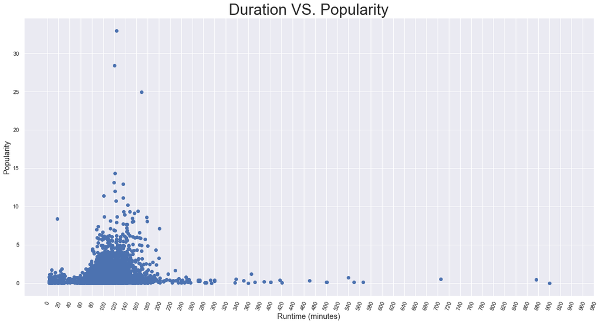

```python
ticks = np.arange(0,1000,20)
f, ax = plt.subplots(figsize=(20,10))
plt.scatter(df.runtime, df.popularity)
plt.title('Duration VS. Popularity', fontsize=30)
plt.xlabel('Runtime (minutes)', fontsize=15)
plt.ylabel('Popularity',fontsize=15)
plt.xticks(ticks, rotation=70);
```

### The scatter plot here shows that the movies with duration range of **80 - 200 minutes** are the most popular movies

## Q: What is the average popularity per year?

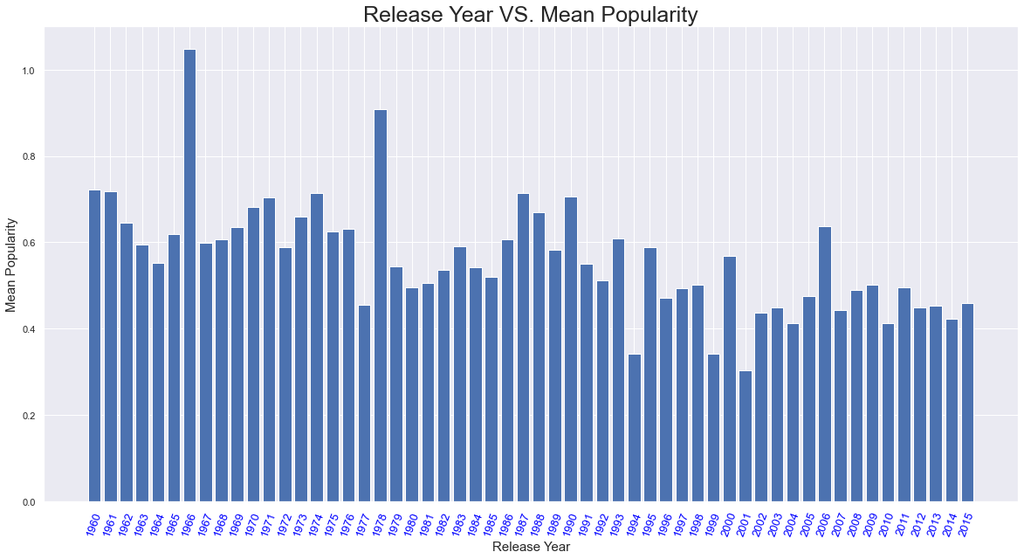

```python
mean_popularity = df.groupby('release_year').popularity.mean()
release_year = df.release_year.unique()
f, ax = plt.subplots(figsize=(20,10))
plt.bar(release_year, mean_popularity)
plt.title('Release Year VS. Mean Popularity', fontsize=25)
plt.xlabel('Release Year', fontsize=15)
plt.ylabel('Mean Popularity', fontsize=15)
plt.xticks(release_year, rotation=70, fontsize=13, color='blue');
```

## Q: What are the genres that are most popular?

### We will assign only one genre (the first of each sublist or the main genre) to each movie and add it to a new dataframe

### copy to a new dataframe

```python
df_genres = df.copy()
```

### extract genres column to a list

```python
list_of_genres = df_genres.genres.tolist()
```

### def a function that takes list of lists as argument and return list of the first element of each sublist

```python
def extract(lst):
    return [item[0] for item in lst]
```

### convert list of genres to pandas series to replace original genres column

```python
list_of_genres = pd.Series(extract(list_of_genres))
```

### replace genres column with new genres list

```python
df_genres.genres = list_of_genres
```

### plot a pie chart for popularity according to genres

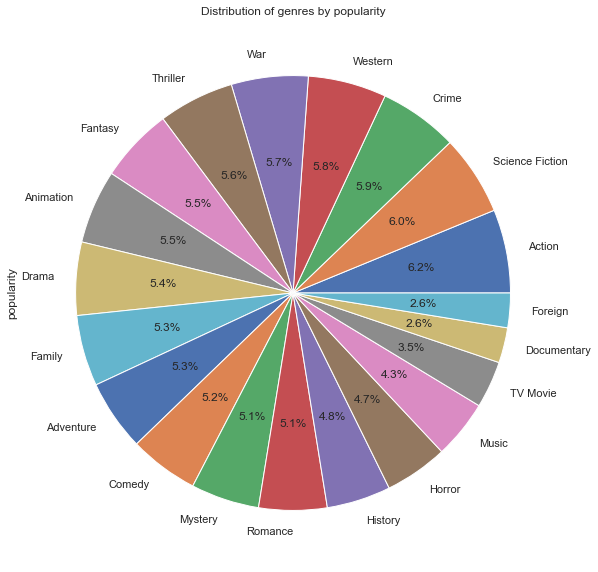

```python
popularity_by_genres = df_genres.groupby('genres').popularity.mean().sort_values(ascending=False)
popularity_by_genres.plot(kind='pie', figsize=(20,10), autopct = '%1.1f%%', title='Distribution of genres by popularity');
```

### So, the most popular genre is **action** followed by **science fiction**

### To my surprise, **Documentaries** comes second to last!

## Q: Who is the main actor that most affect popularity?

### I did some research on the internet and found that the first actor in 'cast' is the main actor of each movie, so let's edit this column to be of main actors only

### Make a new dataframe and extract the first actor of each cast to a new series then replace the cast column with the new one

```python
df_cast = df.copy()
cast_list = df_cast.cast.tolist()
cast_list = pd.Series(extract(cast_list))
df_cast.cast = cast_list
```

### Let's check how many different actors are there

```python
df_cast.cast.nunique()
```

```
4233
```

### So it wouldn't look nice to plot 4233 actors in one plot, instead let's check who are the top 20 actors that affect popularity

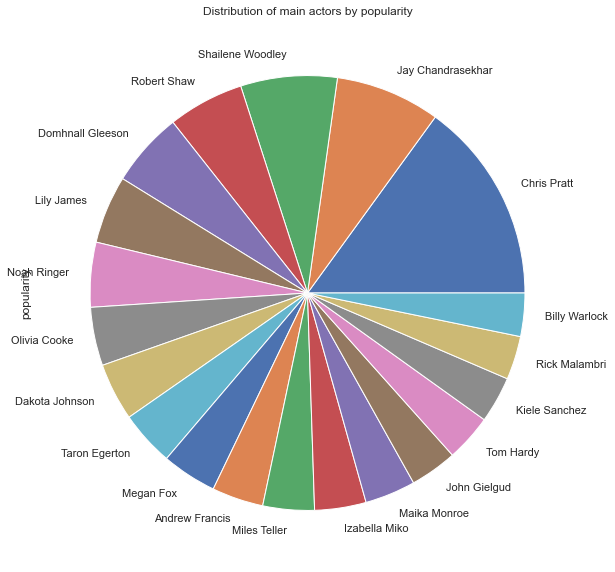

```python
popularity_by_actor = df_cast.groupby('cast').popularity.mean().sort_values(ascending=False)[0:20]
popularity_by_actor.plot(kind='pie', figsize=(20,10), title='Distribution of main actors by popularity');
```

### So, it seems Chris Pratt contributes most to popularity -However I think that's because his movie Jurassic World is the most popular among them all-

## Q: Which director contributes most to popularity?

[figure not shown]

```python
popularity_by_director = df.groupby('director').popularity.mean().sort_values(ascending=False)[0:10]
director_plot = popularity_by_director.plot(kind='bar', figsize=(20,10))
director_plot.set_title('Top 20 Director by Average Popularity', fontsize=20)
director_plot.set_xlabel('Director', fontsize=15)
director_plot.set_ylabel('Average Popularity', fontsize=15)
director_plot;
```

### So, the plot shows that **Colin Trevorrow** (Director of Jurassic world saga) movies are the most popular, with **Christopher Nolan** in tenth position!

# Profitability

### In this category, we will explore our dataset according to profitability

## These reults may have a degree of inaccuracy because of the **data limitations** which is due to filling out the NaN values in revenue_adj column with the mean value

## Q: How does movie duration affect profitability?

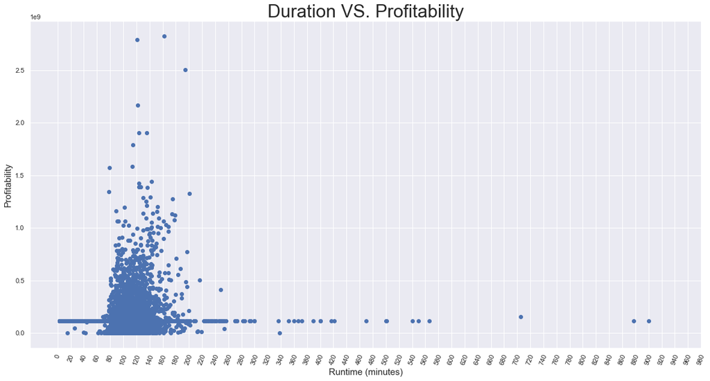

```python
f, ax = plt.subplots(figsize=(20,10))
plt.scatter(df.runtime, df.revenue_adj)
plt.title('Duration VS. Profitability', fontsize=30)
plt.xlabel('Runtime (minutes)', fontsize=15)
plt.ylabel('Profitability',fontsize=15)
plt.xticks(ticks, rotation=70);
```

### It seems here that the most profitable movies are in the duration range of **80 - 200 minutes**, which is nearly the same range of the most popular movies

## Q: What is the average revenue by year?

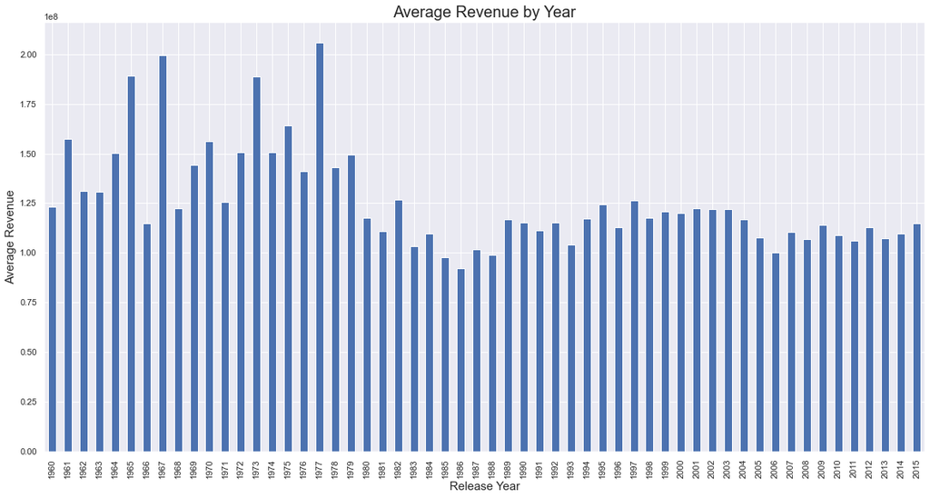

```python
average_revenue_by_year = df.groupby('release_year').revenue_adj.mean()
year_plot = average_revenue_by_year.plot(kind='bar', figsize=(20,10))
year_plot.set_title('Average Revenue by Year', fontsize=20)
year_plot.set_xlabel('Release Year', fontsize=15)
year_plot.set_ylabel('Average Revenue', fontsize=15)
year_plot;
```

### From the bar plot above, it shows that the movies in the years from 1960 - 1980 have made more average revenue than later years, with year **1977** making the most average revenue while **1986** making the least average revenue

## Q: Which genres are the most profitable?

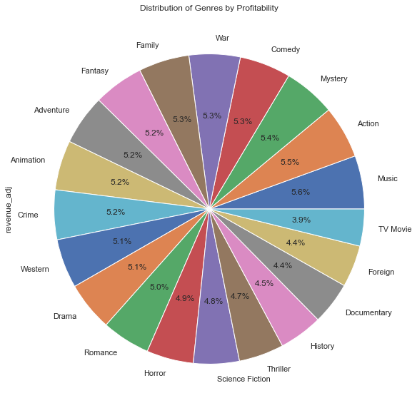

```python
profitability_by_genre = df_genres.groupby('genres').revenue_adj.mean().sort_values(ascending=False)
profitability_by_genre.plot(kind='pie', figsize=(20,10), autopct = '%1.1f%%', title='Distribution of Genres by Profitability');
```

### That's interesting! Although Music Genre is one of the least 5 popular genres, it comes **first** in terms of profitability! However it's nearly equal to Action Genre in terms of profitability which is the most popular genre (logic)

## Q: Which main actor contributes most to profitability?

### Let's plot the top 20 actors affecting profitability

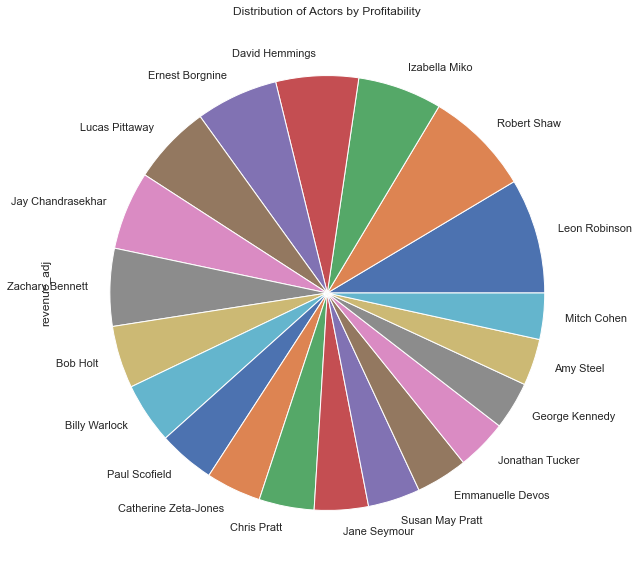

```python
profitability_by_actor = df_cast.groupby('cast').revenue_adj.mean().sort_values(ascending=False)[0:20]
profitability_by_actor.plot(kind='pie', figsize=(20,10), title='Distribution of Actors by Profitability');
```

### The pie chart shows that **Leon Robinson** is the main actor that contributed most to profitability who is not even in the top 20 most popular main actors!

# Frequency

### In this last category we are going to explore our dataset with frequency of properties

## Q: What is the most frequent genre?

```python
list_of_genres.mode()[0]
```

```
'Drama'
```

### Generate a pie chart distributing the genres frequency

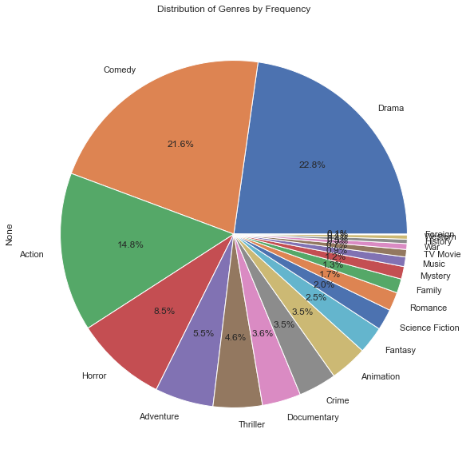

```python
list_of_genres.value_counts().plot(kind='pie', figsize=(20,10), autopct = '%1.1f%%', title='Distribution of Genres by Frequency');
```

## Interesting!

### Although the most popular genre is (Action), it comes **third** in terms of frequency.

### Also, Although (Drama) appears to be the most frequent genre, it comes **ninth** in terms of popularity

## Q: Who is the most appearing actor?

### Define a function to take a column of list of lists as an argument and returns a pandas series of flat list of all items in sublists

```python
def flat(column):
    flat_list=[]
    list_of_sublists = df[column].tolist()
    for sublist in list_of_sublists:
        for item in sublist:
            flat_list.append(item)
    flat_list = pd.Series(flat_list)
    return flat_list
```

### Make a flat list of all actors

```python
list_of_actors = flat('cast')
```

### The most frequent actor

```python
list_of_actors.mode()[0]
```

```
'Robert De Niro'
```

## Of course it's **Robert De Niro**!

### Plot the top 20 most appearing actors

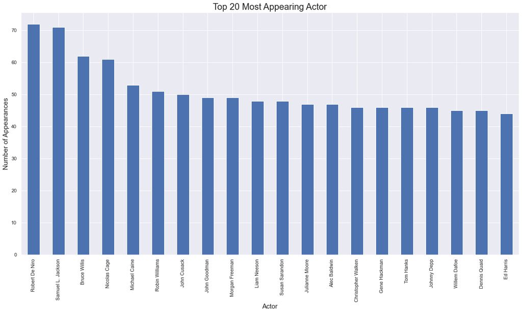

```python
actors_plot = list_of_actors.value_counts()[0:20].plot(kind='bar', figsize=(20,10))
actors_plot.set_title('Top 20 Most Appearing Actor', fontsize=20)
actors_plot.set_xlabel('Actor', fontsize=15)
actors_plot.set_ylabel('Number of Appearances', fontsize=15)
actors_plot;
```

## Q: Who is the most frequent director?

```python
df.director.mode()[0]
```

```
'Woody Allen'
```

### **Plot the top 20 most frequent director**

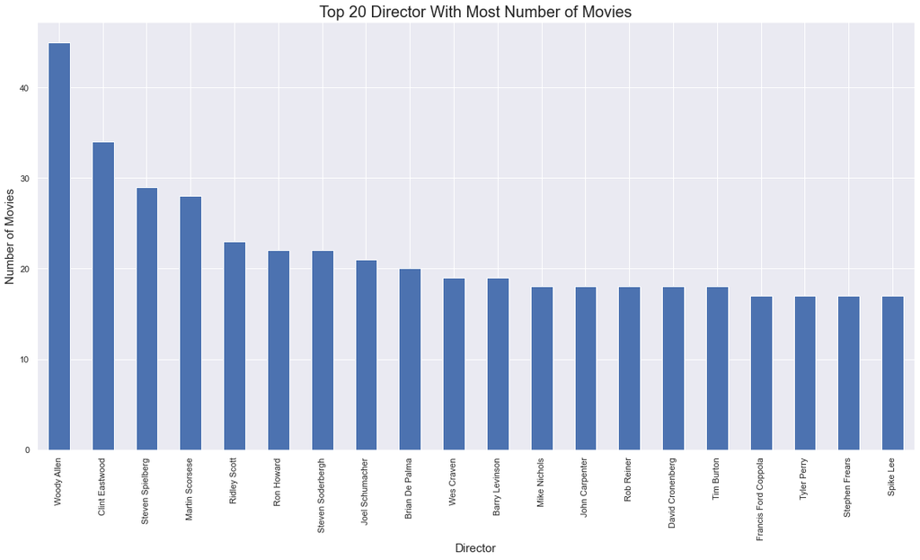

```python
director_frequency = df.director.value_counts()[0:20].plot(kind='bar', figsize=(20,10))
director_frequency.set_title('Top 20 Director With Most Number of Movies', fontsize=20)
director_frequency.set_xlabel('Director', fontsize = 15)
director_frequency.set_ylabel('Number of Movies', fontsize = 15);
```

### It appears that **Woody Allen** is the director that made the most number of movies with more than 40 movies! However in terms of popularity he is not even in the top 20!

# Conclusions

At the end of this project, I realized that it's not necessary if a director for example has produced a large number of movies that he be the most succesful or the most popular, as we saw "Woody Allen" for example; he made more than 40 movies, however he is not the one with the most average popular or profitable movie, It depends on other factors.

Also we can use the analysis of this dataset to conclude that if a production company wants to make a popular and profitable movie at the same time, this movie should fall in the range of **80-200 minutes** duration not more or less. Also the production company would go for Action, Science Fiction movies for popularity while it should go for Musicals for profitability, However "Action" genre appears to be the most succesful genre as it lies within the top in terms of popularity , profitability, and frequency.

I always thought that documentaries are so popular, but after investigating here, it lies within the least popular movies, also they are not so profitable.

Although "Drama" movies are not the most popular nor the most profitable genre, production companies go for it most of the time, maybe there is another factor that drives them, which does not appear here in this dataset! (Interesting, this needs more investigation)

### Limitations: Filling the missing values in budget, revenue, and runtime columns with the mean value of each column (more than 4000 entry) could affect the results and provide a degree of inaccuracy

Finally, For me this was a very interesting project, I learned alot going through every part of it, I came to great findings about something that I am passionate for, and also learned that what you think about sth. may not always be right, just go and do some investigations to prove your point of view or maybe you find that your point of view is not the best. The project has inspired me to do more investigations about the things I am passionate for in order to come out with very interesting findings and conclusions.